# The Role of Problem- and Emotion-Focused Coping in the Prediction of Blood Pressure and Hypertension

## 0.1 Preliminaries

```r
library(tidyverse); library(here) # set_here()
library(haven); library(mice); library(simputation); library("GGally"); library(Hmisc); library(broom)
library(pROC); library(rms)
```

# 1 Task 1: Data Source

I will be using data from the Midlife in the United States (MIDUS) study. Originally started by the MacArthur Midlife Research Network in 1995-1996, The goal of the study was to investigate the role of behavioral, psychological, and social factors in understanding age-related differences in physical and mental health. With funding from the National Institute on Aging, there was a MIDUS Refresher initiative, which focused on gathering data from younger members of the new sample, age matched on the original MIDUS sample from 1995. Approximately 2,100 individual ages (25-54) were recruited, along with 1,400 individuals in older ages, in order to “refresh” the sample of original members.

Probability sampling was used, by landline and cellphone telephone sampling frames

I accessed this data set on the ICPSR website:

[MIDUS/ICPSR link](https://www.icpsr.umich.edu/icpsrweb/ICPSR/studies/36532?q=midus)

# 2 Task 2: Load and Tidy the Data

## 2.1 Variable and Recoding

```r
setwd(here("midus_data"))



raw <- read_dta("36346-0001-Data.dta") %>%
  tbl_df %>%
  select(M2ID, C1SA11S, C1PA25BS, C1PA25BD, C1PRAGE, C1PRSEX, C1PA11, C1SPRCOP, C1SEMCOP) %>%
  sample_n(1000, replace = FALSE, weight = NULL, .env = NULL)

# ID# - M2ID
# High blood pressure/hypertension ever (12 months): C1SA11S
# Exact reading systolic blood pressure - C1PA25BS
# Exact reading diastolic blood pressure - C1PA25BD
# Age - C1PRAGE
# Sex - C1PRSEX 1 = MALE, 2 = FEMALE
# How much worry about your heart - C1PA11
# Problem Focused Coping - C1SPRCOP
# Emotion Focused Coping - C1SEMCOP


tidy_bp <- raw %>%
  tbl_df %>%
  rename(
    ID = M2ID,
    bp_hyperten = C1SA11S,
    systolic = C1PA25BS,
    diastolic = C1PA25BD,
    age = C1PRAGE,
    male = C1PRSEX,
    worry_heart = C1PA11,
    prob_cope =  C1SPRCOP,
    emot_cope = C1SEMCOP) %>%
    mutate(worry_heart = as.factor(case_when(worry_heart == 1 ~ "A lot", #recode worry_heart
                                 worry_heart == 2  ~ "Some",
                                 worry_heart == 3  ~ "A little",
                                 worry_heart == 4  ~ "Not at all",
                                 ))
         )

### Recode bp_hyperten
  tidy_bp$bp_hyperten[tidy_bp$bp_hyperten ==  -1 ] <- NA #RESPONDENT DOES NOT HAVE SAQ DATA
  tidy_bp$bp_hyperten[tidy_bp$bp_hyperten ==  2 ] <- 0
  tidy_bp$bp_hyperten[tidy_bp$bp_hyperten == 8 ] <- NA #REFUSED

### Recode male
  tidy_bp$male[tidy_bp$male ==  2 ] <-  0

### Recode prob_cope
  tidy_bp$prob_cope[tidy_bp$prob_cope ==  -1 ] <- NA #RESPONDENT DOES NOT HAVE SAQ DATA
  tidy_bp$prob_cope[tidy_bp$prob_cope ==  98 ] <- NA #NOT CALCULATED (Due to missing data)

### Recode emot_cope
  tidy_bp$emot_cope[tidy_bp$emot_cope ==  -1 ] <- NA #RESPONDENT DOES NOT HAVE SAQ DATA
  tidy_bp$emot_cope[tidy_bp$emot_cope ==  98 ] <- NA #NOT CALCULATED (Due to missing data)

### Recode systolic
  tidy_bp$systolic[tidy_bp$systolic ==  997 ] <- NA #DON'T KNOW
  tidy_bp$systolic[tidy_bp$systolic ==  998 ] <- NA #REFUSED
  tidy_bp$systolic[tidy_bp$systolic ==  999 ] <- NA #INAPP

### Recode diastolic
  tidy_bp$diastolic[tidy_bp$diastolic ==  997 ] <- NA #DON'T KNOW
  tidy_bp$diastolic[tidy_bp$diastolic ==  998 ] <- NA #REFUSED
  tidy_bp$diastolic[tidy_bp$diastolic ==  999 ] <- NA #INAPP
```

Data Tidying Summary: I selected the relevant variables and renamed them to understandable titles. I then recoded `sex` to a dummy-coded `male` variable. I also recoded `bp_hyperten` (In the past twelve months, have you experienced or been treated for any of the following - high blood pressure or hypertension?) to dummy code it and recode missing variable codes to NA. I also coded missing data values identified in the study documention for `prob_cope`, `emot_cope`, `systolic`, and `diastolic`.

## 2.2 Missingness Check

After recoding missing values as NA, I checked the number of missing values for all the variables.

```r
colSums(is.na(tidy_bp))
```

```
         ID bp_hyperten    systolic   diastolic         age        male
          0         190         389         403           0           0
worry_heart   prob_cope   emot_cope
          0         182         183
```

# 3 Task 3: Listing of My Tibble

```r
glimpse(tidy_bp)
```

```
Observations: 1,000
Variables: 9
$ ID          <dbl> 12690, 18571, 18942, 18550, 14163, 16153, 10432, 1...
$ bp_hyperten <dbl+lbl> 0, 0, 1, 1, 1, 0, 1, 0, 0, 1, 1, NA, 0, NA, 0,...
$ systolic    <dbl+lbl> 115, 110, 174, 150, NA, 120, 139, 116, 110, 12...
$ diastolic   <dbl+lbl> 76, 60, 80, 80, NA, 60, 84, 80, 70, 78, 63, NA...
$ age         <dbl> 66, 47, 74, 71, 52, 54, 69, 82, 71, 75, 77, 79, 44...
$ male        <dbl+lbl> 0, 0, 1, 1, 1, 0, 0, 0, 1, 0, 0, 0, 0, 1, 0, 0...
$ worry_heart <fct> Not at all, Not at all, A little, Not at all, A li...
$ prob_cope   <dbl+lbl> 26, 43, 41, 42, 42, 37, 41, 40, 43, 39, 22, NA...
$ emot_cope   <dbl+lbl> 14.00000, 15.00000, 18.00000, 19.00000, 20.000...
```

```r
str(tidy_bp)
```

```
Classes 'tbl_df', 'tbl' and 'data.frame':   1000 obs. of  9 variables:
 $ ID         : num  12690 18571 18942 18550 14163 ...
 $ bp_hyperten:Classes 'labelled', 'numeric'  atomic [1:1000] 0 0 1 1 1 0 1 0 0 1 ...
  .. ..- attr(*, "label")= chr "High blood pressure/hypertension ever (12 months)"
 $ systolic   :Classes 'labelled', 'numeric'  atomic [1:1000] 115 110 174 150 NA 120 139 116 110 126 ...
  .. ..- attr(*, "label")= chr "Exact reading systolic blood pressure"
 $ diastolic  :Classes 'labelled', 'numeric'  atomic [1:1000] 76 60 80 80 NA 60 84 80 70 78 ...
  .. ..- attr(*, "label")= chr "Exact reading diastolic blood pressure"
 $ age        : num  66 47 74 71 52 54 69 82 71 75 ...
 $ male       :Classes 'labelled', 'numeric'  atomic [1:1000] 0 0 1 1 1 0 0 0 1 0 ...
  .. ..- attr(*, "label")= chr "Respondent's sex"
 $ worry_heart: Factor w/ 4 levels "A little","A lot",..: 3 3 1 3 1 4 4 1 3 1 ...
 $ prob_cope  :Classes 'labelled', 'numeric'  atomic [1:1000] 26 43 41 42 42 37 41 40 43 39 ...
  .. ..- attr(*, "label")= chr "Problem Focused Coping"
 $ emot_cope  :Classes 'labelled', 'numeric'  atomic [1:1000] 14 15 18 19 20 28 33 15 25 24 ...
  .. ..- attr(*, "label")= chr "Emotion Focused Coping"
```

*Dimensions of tibble: **1000** subjects [rows] and **9** variables [columns]*

# 4 Task 4: Code Book

| Variable | Type | Details |
| --- | --- | --- |
| `ID` | Integer | Midus identification code (10001 to 19190) |
| `bp_hyperten` | binary | Participant’s report of high blood pressure/hypertension in last 12 months |
| `systolic` | quantitative | Exact reading of systolic blood pressure (in mmHg) |
| `diastolic` | quantitative | Exact reading of diastolic blood pressure (in mmHg) |
| `age` | quantitative | Participant’s age (in years) |
| `male` | binary | Dummy variable of sex (Male = 1, Female = 0) |
| `worry_heart` | multi-categorical | “How much worry about your heart”: Values - “Not at all”, “A little”, “Some”, “A lot” |
| `prob_cope` | quantitative | Problem Focused Coping |
| `emot_cope` | quantitative | Emotion Focused Coping |

# 5 Task 5: My Subjects

The data consists of middle- and older-aged adults from the U.S. They are aged between 42-93 years (*M* = 63.4, *SD* = 11.37).

# 6 Task 6: My Variables

- **ID** - This is a unique identifier, provided by the Midlife in the United States (MIDUS) study.
- **bp_hyperten** - A yes/no variable to the question: In the past twelve months, have you experienced or been treated for any of the following - High blood pressure or hypertension?
- **systolic** - A quantitative variable of the exact reading of the participant’s systolic blood pressure (in mmHg)
- **diastolic** - A quantitative variable of the exact reading of the participant’s diastolic blood pressure (in mmHg)
- **age** - Participant’s age (in years)
- **male** - A dummy coded variable for participant’s sex (Male = 1, Female = 0)
- **worry_heart** - A multi-categorical variable to the question: How much do you worry about your heart: a lot, some, a little, or not at all?
- **prob_cope** - A quantitative measure of problem-focused coping. This variable was created by combining 12 items from three subscales (âPositive Reinterpretation and Growth,â âActive Coping,â and âPlanning.â) from a questionnaire from Carver et al. (1989). Items are on a 4-point Likert scale (1 = A lot; 2 = A medium amount; 3 = Only a little; 4 = Not at all). Scales were constructed by calculating the sum of the values of the items in each scale. Items were reverse-coded so that high scores reflect higher standing in the scale
- **emot_cope** - A quantitative measure of emotion-focused coping. This variable was created by combining 12 items from three subscales (âFocus on and venting of emotion,â âDenial,â and âBehavioral disengagement.â) from a questionnaire from Carver et al. (1989). Items are on a 4-point Likert scale (1 = A lot; 2 = A medium amount; 3 = Only a little; 4 = Not at all). Scales were constructed by calculating the sum of the values of the items in each scale. Items were reverse-coded so that high scores reflect higher standing in the scale

Reference:

Carver, C. S., Scheier, M. F. & Weintraub, J. K. (1989). Assessing coping strategy: A theoretical based approach. Journal of Personality and Social Psychology, 56, 267-283.

# 7 Task 7: My Planned Linear Regression Model

I plan on fitting a linear regression model for systolic blood pressure (in mmHg). The predictors will be `age`, `male`, `worry_heart`, `prob_cope`, and `emot_cope`. I’m predicting that problem-solving coping with be negatively related to systolic blood pressure. In contrast emotion-focused coping is hypothesized to be positively predictive of systolic blood pressure.

# 8 Task 8: My Planned Logistic Regression Model

I plan on fitting one logistic regression model, for the participant’s yes/no report of high blood pressure/hypertension in last 12 months. The predictors will be `age`, `male`, `worry_heart`, `prob_cope`, and `emot_cope`. I’m predicting that problem-solving coping with be negatively related to both measures of blood pressure. In contrast emotion-focused coping is hypothesized to be positively predictive of the measures of blood pressure.

# 9 Task 9: Affirmation

- These data meet all requirements specified in the project instructions.
- With 1000 randomly sampled observations, it falls between the minimum (100) and maximum (1000) sample size.
- It contains 5 predictors, three being quantitative, one being binary, and one being multi-categorical.
- One outcome variable is binary and two outcome variables are quantitative.
- I am certain that it is completely appropriate for these data to be shared with anyone, without any conditions. There are no concerns about privacy or security.

# 10 Task 10 Analysis: Linear Regression

## 10.1 Correlations between Outcome and Predictors

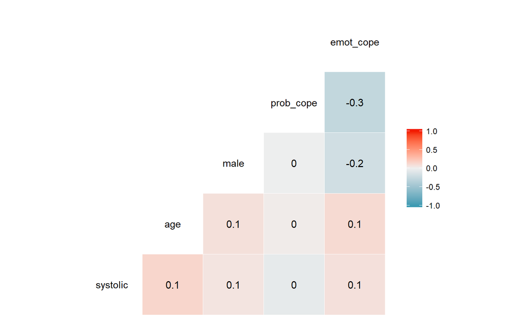

```r
analyses1 <- tidy_bp %>%
  select(systolic, age, male, worry_heart, prob_cope, emot_cope) %>%
  filter(complete.cases(.))

# Correlation plot
ggcorr(analyses1, palette = "RdBu", label = TRUE)
```

## 10.2 Distribution of the Outcome

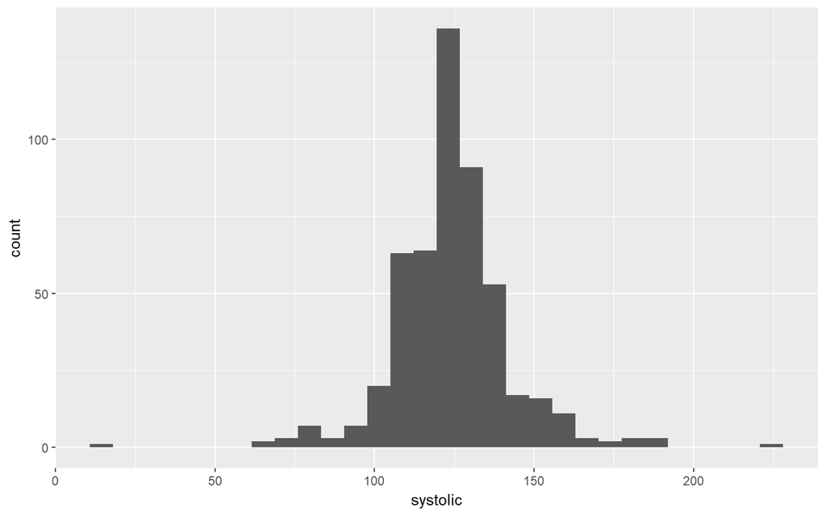

```r
ggplot(analyses1, aes(x=systolic)) +
    geom_histogram()
```

Though we have a pretty high middle point in the histogram, it is fairly normal in shape.

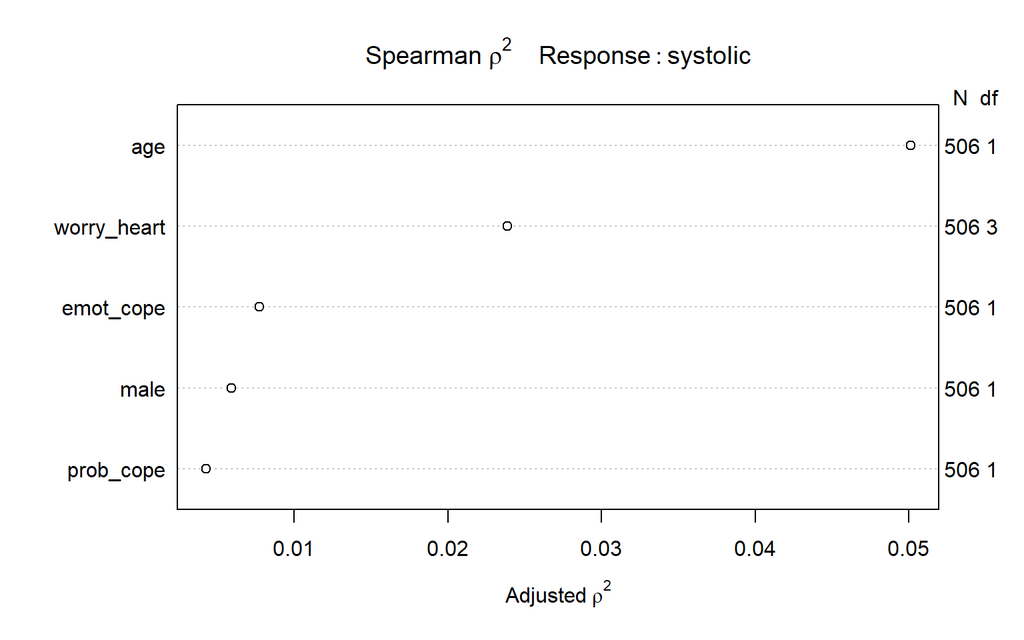

```r
spear.bp <- spearman2(systolic ~ male + age + worry_heart + prob_cope + emot_cope, data = analyses1)

plot(spear.bp)
```

```r
m0 <- lm(systolic ~ male + age + worry_heart + prob_cope + emot_cope, data = analyses1)

summary(m0)
```

```
Call:
lm(formula = systolic ~ male + age + worry_heart + prob_cope +
    emot_cope, data = analyses1)

Residuals:
Exact reading systolic blood pressure
     Min       1Q   Median       3Q      Max
-115.020   -7.518   -1.415    7.464   98.890

Coefficients:
                       Estimate Std. Error t value Pr(>|t|)
(Intercept)           108.47761    8.34513  12.999  < 2e-16 ***
male                    2.35062    1.63044   1.442  0.15001
age                     0.23607    0.07680   3.074  0.00223 **
worry_heartA lot        3.75998    4.58815   0.819  0.41289
worry_heartNot at all  -5.14951    1.94696  -2.645  0.00843 **
worry_heartSome        -0.03074    2.10654  -0.015  0.98836
prob_cope              -0.07706    0.13578  -0.568  0.57063
emot_cope               0.18240    0.16015   1.139  0.25527
---
Signif. codes:  0 '***' 0.001 '**' 0.01 '*' 0.05 '.' 0.1 ' ' 1

Residual standard error: 17.76 on 498 degrees of freedom
Multiple R-squared:  0.05026,   Adjusted R-squared:  0.03691
F-statistic: 3.765 on 7 and 498 DF,  p-value: 0.0005445
```

```r
glance(m0)
```

```
   r.squared adj.r.squared    sigma statistic      p.value df    logLik
1 0.05026312     0.0369134 17.76118  3.765108 0.0005445469  8 -2169.721
       AIC     BIC deviance df.residual
1 4357.442 4395.48 157098.9         498
```

```r
m1 <- lm(systolic ~ male + age + prob_cope + emot_cope, data = analyses1)

summary(m1)
```

```
Call:
lm(formula = systolic ~ male + age + prob_cope + emot_cope, data = analyses1)

Residuals:
Exact reading systolic blood pressure
     Min       1Q   Median       3Q      Max
-113.264   -7.707   -1.374    8.134  100.941

Coefficients:
             Estimate Std. Error t value Pr(>|t|)
(Intercept) 107.40029    8.19280  13.109  < 2e-16 ***
male          2.09780    1.63788   1.281  0.20085
age           0.22266    0.07703   2.890  0.00401 **
prob_cope    -0.09949    0.13594  -0.732  0.46459
emot_cope     0.22853    0.16020   1.427  0.15434
---
Signif. codes:  0 '***' 0.001 '**' 0.01 '*' 0.05 '.' 0.1 ' ' 1

Residual standard error: 17.91 on 501 degrees of freedom
Multiple R-squared:  0.02851,   Adjusted R-squared:  0.02075
F-statistic: 3.676 on 4 and 501 DF,  p-value: 0.005807
```

```r
glance(m1)
```

```
   r.squared adj.r.squared    sigma statistic     p.value df   logLik
1 0.02851067    0.02075427 17.90957   3.67576 0.005807037  5 -2175.45
     AIC      BIC deviance df.residual
1 4362.9 4388.259 160697.1         501
```

```r
m2 <- lm(systolic ~ male + age + prob_cope + emot_cope + age:emot_cope, data = analyses1)

summary(m2)
```

```
Call:
lm(formula = systolic ~ male + age + prob_cope + emot_cope +
    age:emot_cope, data = analyses1)

Residuals:
Exact reading systolic blood pressure
     Min       1Q   Median       3Q      Max
-112.928   -7.802   -1.398    7.798  100.723

Coefficients:
              Estimate Std. Error t value Pr(>|t|)
(Intercept)   87.65973   22.32834   3.926 9.85e-05 ***
male           2.09233    1.63804   1.277    0.202
age            0.51780    0.31995   1.618    0.106
prob_cope     -0.08385    0.13694  -0.612    0.541
emot_cope      1.09898    0.92978   1.182    0.238
age:emot_cope -0.01335    0.01405  -0.950    0.342
---
Signif. codes:  0 '***' 0.001 '**' 0.01 '*' 0.05 '.' 0.1 ' ' 1

Residual standard error: 17.91 on 500 degrees of freedom
Multiple R-squared:  0.03026,   Adjusted R-squared:  0.02057
F-statistic: 3.121 on 5 and 500 DF,  p-value: 0.008744
```

```r
glance(m2)
```

```
   r.squared adj.r.squared   sigma statistic     p.value df    logLik
1 0.03026255    0.02056517 17.9113  3.120695 0.008743681  6 -2174.993
       AIC      BIC deviance df.residual
1 4363.987 4393.573 160407.3         500
```

```r
m3 <- lm(systolic ~ male + age + prob_cope + emot_cope + age:emot_cope + male:emot_cope, data = analyses1)

summary(m3)
```

```
Call:
lm(formula = systolic ~ male + age + prob_cope + emot_cope +
    age:emot_cope + male:emot_cope, data = analyses1)

Residuals:
Exact reading systolic blood pressure
     Min       1Q   Median       3Q      Max
-111.516   -7.419   -1.524    7.703  101.214

Coefficients:
               Estimate Std. Error t value Pr(>|t|)
(Intercept)    81.59427   22.64763   3.603 0.000346 ***
male           12.22765    6.81948   1.793 0.073571 .
age             0.52769    0.31959   1.651 0.099335 .
prob_cope      -0.07258    0.13695  -0.530 0.596367
emot_cope       1.35333    0.94328   1.435 0.151998
age:emot_cope  -0.01388    0.01403  -0.989 0.323260
male:emot_cope -0.46798    0.30569  -1.531 0.126421
---
Signif. codes:  0 '***' 0.001 '**' 0.01 '*' 0.05 '.' 0.1 ' ' 1

Residual standard error: 17.89 on 499 degrees of freedom
Multiple R-squared:  0.0348,    Adjusted R-squared:  0.02319
F-statistic: 2.998 on 6 and 499 DF,  p-value: 0.006908
```

```r
glance(m3)
```

```
   r.squared adj.r.squared    sigma statistic     p.value df    logLik
1 0.03479599    0.02319033 17.88728  2.998192 0.006907571  7 -2173.808
       AIC      BIC deviance df.residual
1 4363.616 4397.428 159657.4         499
```

However, I also need to assess whether the original interaction I added (i.e., age and emotion-focused coping) is significantly adding to the main effects model without `worry_heart`

```r
anova(m1,m2)
```

```
Analysis of Variance Table

Model 1: systolic ~ male + age + prob_cope + emot_cope
Model 2: systolic ~ male + age + prob_cope + emot_cope + age:emot_cope
  Res.Df    RSS Df Sum of Sq      F Pr(>F)
1    501 160697
2    500 160407  1    289.78 0.9033 0.3424
```

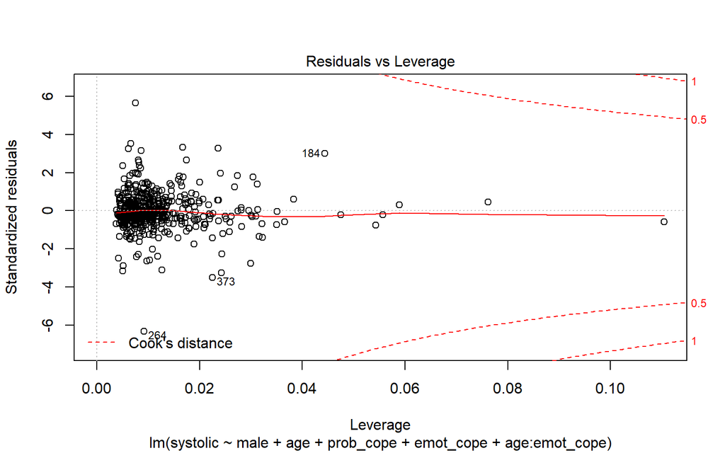

```r
plot(m2, which = 5)
```

I don’t see any highly influential points, as no points fall outside of the Cook’s distance

# 11 Task 11 Analysis: Logistic Regression

As with the firsr analyses, I select relevant variables and filter on complete cases:

```r
analyses2 <- tidy_bp %>%
  select(bp_hyperten, age, male, worry_heart, prob_cope, emot_cope) %>%
  filter(complete.cases(.))
```

I then create a spearman’s rho plot:

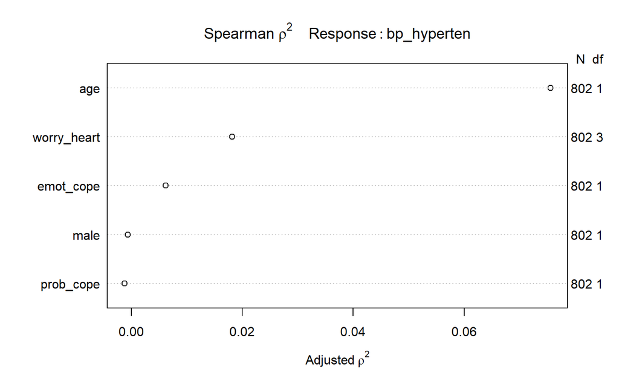

```r
spear.bp <- spearman2(bp_hyperten ~ male + age + worry_heart + prob_cope + emot_cope, data = analyses2)

plot(spear.bp)
```

Only age seems like a good predictor in this plot

Now, I fit the main effects model:

```r
m0a <- glm(bp_hyperten ~ male + age + worry_heart + prob_cope + emot_cope, data = analyses2, family = binomial)

summary(m0a)
```

```
Call:
glm(formula = bp_hyperten ~ male + age + worry_heart + prob_cope +
    emot_cope, family = binomial, data = analyses2)

Deviance Residuals:
    Min       1Q   Median       3Q      Max
-2.1819  -0.9573  -0.6930   1.1795   1.8783

Coefficients:
                       Estimate Std. Error z value Pr(>|z|)
(Intercept)           -4.132824   0.801013  -5.159 2.48e-07 ***
male                  -0.089570   0.156043  -0.574  0.56596
age                    0.055317   0.007466   7.409 1.28e-13 ***
worry_heartA lot       1.186581   0.467955   2.536  0.01122 *
worry_heartNot at all -0.526451   0.181848  -2.895  0.00379 **
worry_heartSome        0.089134   0.200944   0.444  0.65735
prob_cope              0.003274   0.013005   0.252  0.80121
emot_cope              0.007995   0.014727   0.543  0.58721
---
Signif. codes:  0 '***' 0.001 '**' 0.01 '*' 0.05 '.' 0.1 ' ' 1

(Dispersion parameter for binomial family taken to be 1)

    Null deviance: 1076.35  on 801  degrees of freedom
Residual deviance:  995.02  on 794  degrees of freedom
AIC: 1011

Number of Fisher Scoring iterations: 4
```

```r
glance(m0a)
```

```
  null.deviance df.null    logLik      AIC      BIC deviance df.residual
1      1076.354     801 -497.5091 1011.018 1048.515 995.0183         794
```

Here we see that age is a highly significant predictor of a self report to the question: *“In the past twelve months, have you experienced or been treated for any of the following - High blood pressure or hypertension?”* (`bp_hyperten`) Additionally, we see that people that answered *“Not at all”* were significantly less likely to say yes to `bp_hyperten` than those whoe reported *“A little”* to the question *“How much do you worry about your heart?”*

In line with the previous analyses, I will add an interaction between age and emotion focused coping.

```r
m1a <- glm(bp_hyperten ~ male + age + worry_heart + prob_cope + emot_cope + age:emot_cope, data = analyses2, family = binomial)

summary(m1a)
```

```
Call:
glm(formula = bp_hyperten ~ male + age + worry_heart + prob_cope +
    emot_cope + age:emot_cope, family = binomial, data = analyses2)

Deviance Residuals:
    Min       1Q   Median       3Q      Max
-2.3112  -0.9520  -0.6945   1.1823   1.8564

Coefficients:
                       Estimate Std. Error z value Pr(>|z|)
(Intercept)           -2.237054   2.145876  -1.042   0.2972
male                  -0.094980   0.156286  -0.608   0.5434
age                    0.027670   0.030003   0.922   0.3564
worry_heartA lot       1.203045   0.470225   2.558   0.0105 *
worry_heartNot at all -0.529810   0.181970  -2.912   0.0036 **
worry_heartSome        0.090102   0.201037   0.448   0.6540
prob_cope              0.001632   0.013128   0.124   0.9011
emot_cope             -0.075989   0.089944  -0.845   0.3982
age:emot_cope          0.001262   0.001334   0.946   0.3439
---
Signif. codes:  0 '***' 0.001 '**' 0.01 '*' 0.05 '.' 0.1 ' ' 1

(Dispersion parameter for binomial family taken to be 1)

    Null deviance: 1076.35  on 801  degrees of freedom
Residual deviance:  994.11  on 793  degrees of freedom
AIC: 1012.1

Number of Fisher Scoring iterations: 4
```

```r
glance(m1a)
```

```
  null.deviance df.null    logLik      AIC      BIC deviance df.residual
1      1076.354     801 -497.0562 1012.112 1054.296 994.1123         793
```

The addition of this interaction term didn’t really change my model. To verify, I ran an anova test to see if the added interaction term improved the model at all.

```r
anova(m0a, m1a)
```

```
Analysis of Deviance Table

Model 1: bp_hyperten ~ male + age + worry_heart + prob_cope + emot_cope
Model 2: bp_hyperten ~ male + age + worry_heart + prob_cope + emot_cope +
    age:emot_cope
  Resid. Df Resid. Dev Df Deviance
1       794     995.02
2       793     994.11  1  0.90597
```

```r
roc_m0a <- roc(analyses2$bp_hyperten ~ predict(m0a, type = "response"), ci = TRUE)

roc_m0a
```

```
Call:
roc.formula(formula = analyses2$bp_hyperten ~ predict(m0a, type = "response"),     ci = TRUE)

Data: predict(m0a, type = "response") in 485 controls (analyses2$bp_hyperten 0) < 317 cases (analyses2$bp_hyperten 1).
Area under the curve: 0.6911
95% CI: 0.6546-0.7276 (DeLong)
```

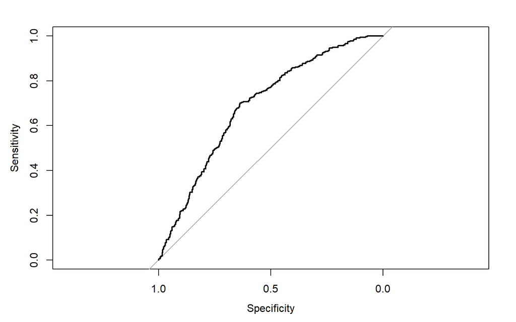

```r
plot(roc_m0a)
```

Next, I created a Residuals vs Leverage plot:

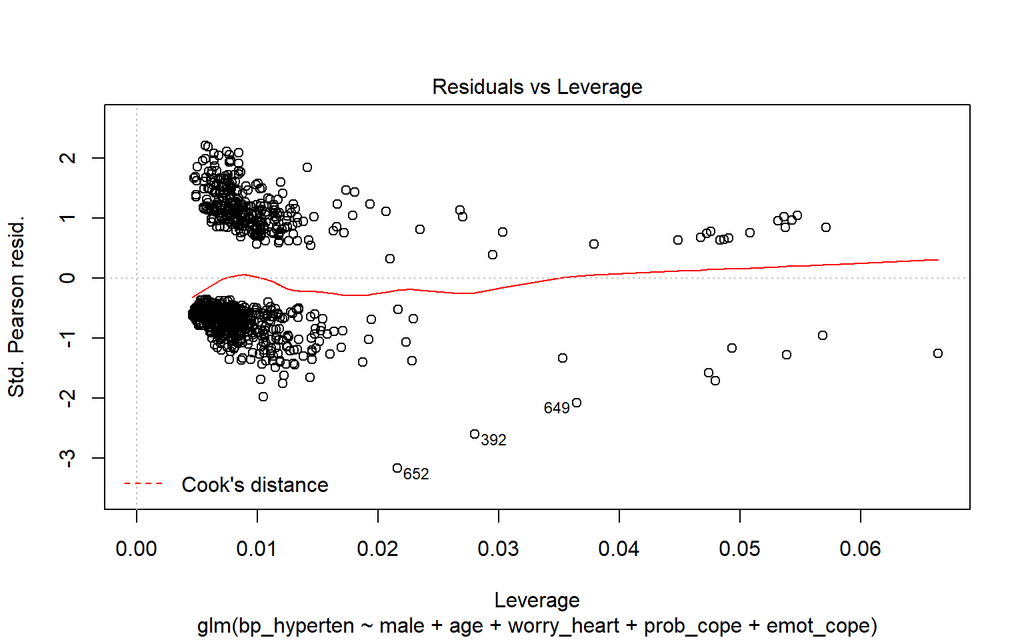

```r
plot(m0a, which = 5)
```

I see no problematic outliers here.

# 12 Task 12: Conclusions

The logistic model was not as successful. Neither coping variable predicted self-report of problems with hypertension or high blood pressure.

Ryan Honomichl

2018-03-08 11:53:27